# CLIMATE 405: Machine Learning for Earth and Environmental Sciences; FALL 2024

## Mohammed Ombadi (ombadi@umich.edu)

# Lecture 14 (Monday, 10/21/2024)

# Topics covered in this lecture:

- Recurrent Neural Networks (RNNs).
- Example of applying RNN for temperature forecasting.
- In-class Excercise.

## Install Tensorflow and dependencies

```python
#!pip install tensorflow
#!pip install pydot
```

## Import libraries

```python
# Import libraries
import os
import sys
import numpy as np
import pandas as pd
import matplotlib.pyplot as plt
import seaborn as sns
import plotly.graph_objects as go
import plotly.express as px
import warnings

from scipy.integrate import odeint
from IPython.display import Image

# Sklearn specific functions used in this lecture
from sklearn.model_selection import train_test_split
from sklearn.preprocessing import LabelEncoder
from sklearn.tree import DecisionTreeClassifier, DecisionTreeRegressor
from sklearn.ensemble import RandomForestRegressor
from sklearn.metrics import classification_report, confusion_matrix
from sklearn.tree import plot_tree
from sklearn.metrics import mean_squared_error, r2_score

# Shapley Interpretation
import shap

# Tensorflow
from tensorflow.keras.models import Sequential
from tensorflow.keras.layers import SimpleRNN, Dense, Flatten
from tensorflow.keras.utils import plot_model

# Suppress warnings
warnings.filterwarnings('ignore')

# Set number of decimals for np print options
np.set_printoptions(precision=3)

# Set the current working directory
os.chdir(sys.path[0])
```

## Recurrent Neural Networks

**Recurrent Neural Networks (RNNs):** a class of neural networks designed to recognize patterns in sequences of data, such as time series, natural language, or sequences of events.

Consider a task with input (**x**) and output (**y**), then the RNN architecture has the following shape:

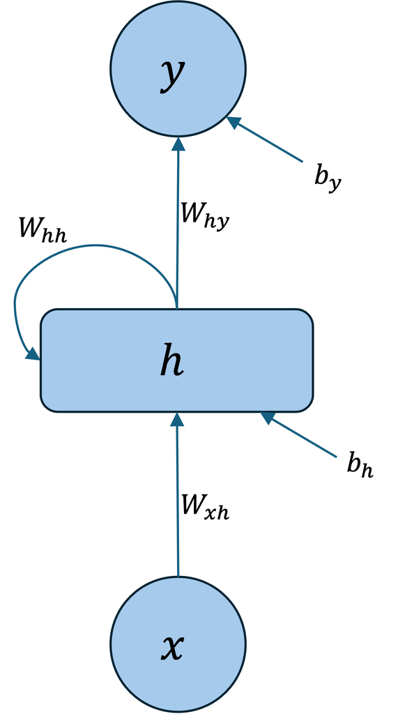

```python
display(Image(filename = 'RNN_architecture.png', width= 350, height= 350))
```

In this Figure,

- $x$ = Input.
- $y$ = Output.
- $h$ = Hidden state.
- $W_{xh}$ = Weights from the input to the hidden layer.
- $W_{hh}$ = Weights from $h_{t-1}$ to $h_{t}$.
- $W_{hy}$ = Weights from the hidden to the output layer.
- $b_{h}$ = bias parameter for the hidden layer.
- $b_{y}$ = bias parameter for the output layer.

The functional form of the RNN is as follows:

$ h_t = \sigma(W_{xh} * x_t + W_{hh} * h_{t-1} + b_h) $

$ y_t = \sigma(W_{hy} * h_t + b_y) $

#### A different way to visualize an RNN (Unfold the network in the time domain):

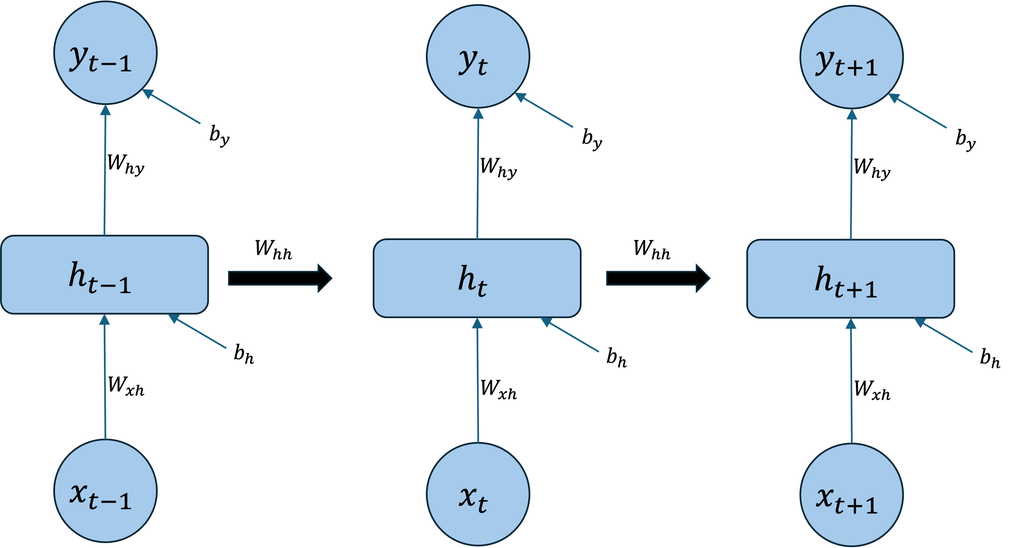

```python
display(Image(filename = 'RNN_unfolded.png', width= 750, height= 600))
```

In this figure:

- $x_{t}$ = Input at time *t*.
- $y_{t}$ = Output at time *t*.
- $h_{t} ; h_{t-1}$ = Hidden state at time *t* and *t-1*, respectively.

## An example of applying Recurrent Neural Networks for Temperature Forecasting

- This is a weather timeseries dataset recorded at the Weather Station at the Max Planck Institute for Biogeochemistry in Jena, Germany.
- The dataset conists of 14 different quantities (such air temperature, atmospheric pressure, humidity, wind direction, and so on).
- They were recorded every 10 minutes, over several years from 2009–2016.

```python
data = pd.read_csv('jena_climate_2009_2016.csv')
print(data.shape)
```

```
(420451, 15)
```

```python
data.head()
```

|  | Date Time | p (mbar) | T (degC) | Tpot (K) | Tdew (degC) | rh (%) | VPmax (mbar) | VPact (mbar) | VPdef (mbar) | sh (g/kg) | H2OC (mmol/mol) | rho (g/m**3) | wv (m/s) | max. wv (m/s) | wd (deg) |
| --- | --- | --- | --- | --- | --- | --- | --- | --- | --- | --- | --- | --- | --- | --- | --- |
| 0 | 01.01.2009 00:10:00 | 996.52 | -8.02 | 265.40 | -8.90 | 93.3 | 3.33 | 3.11 | 0.22 | 1.94 | 3.12 | 1307.75 | 1.03 | 1.75 | 152.3 |
| 1 | 01.01.2009 00:20:00 | 996.57 | -8.41 | 265.01 | -9.28 | 93.4 | 3.23 | 3.02 | 0.21 | 1.89 | 3.03 | 1309.80 | 0.72 | 1.50 | 136.1 |
| 2 | 01.01.2009 00:30:00 | 996.53 | -8.51 | 264.91 | -9.31 | 93.9 | 3.21 | 3.01 | 0.20 | 1.88 | 3.02 | 1310.24 | 0.19 | 0.63 | 171.6 |
| 3 | 01.01.2009 00:40:00 | 996.51 | -8.31 | 265.12 | -9.07 | 94.2 | 3.26 | 3.07 | 0.19 | 1.92 | 3.08 | 1309.19 | 0.34 | 0.50 | 198.0 |
| 4 | 01.01.2009 00:50:00 | 996.51 | -8.27 | 265.15 | -9.04 | 94.1 | 3.27 | 3.08 | 0.19 | 1.92 | 3.09 | 1309.00 | 0.32 | 0.63 | 214.3 |

### Temperature variability over the record period

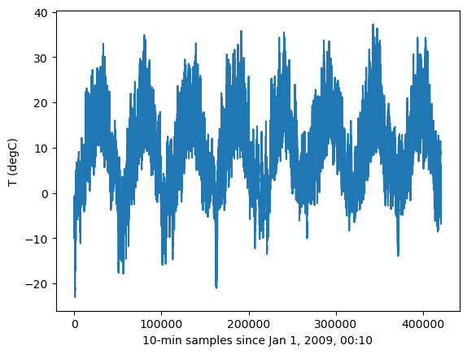

```python
plt.plot(data['T (degC)'])
plt.ylabel('T (degC)')
plt.xlabel('10-min samples since Jan 1, 2009, 00:10')
```

### Temperature variability for a period of 10 days (1440 observations)

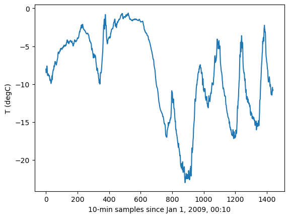

```python
plt.plot(data['T (degC)'][:1440])
plt.ylabel('T (degC)')
plt.xlabel('10-min samples since Jan 1, 2009, 00:10')
```

### Prepare the data to be used for Machine Learning

```python
data = pd.read_csv('jena_climate_2009_2016.csv')

# Keep only the variables and change to a numpy array
variables = data.columns[1:] #List of variables
data = data.iloc[:,1:].values


# Scale the data relative to the mean and standard deviation of the training data
train_data = data[1:200000,]
mean = np.mean(train_data, axis= 0)
std = np.std(train_data, axis= 0)
data = (data - mean) / std #scale the data
```

```python
data
```

```
array([[ 0.9  , -1.931, -1.982, ..., -0.73 , -0.781, -0.276],
       [ 0.906, -1.975, -2.026, ..., -0.931, -0.888, -0.463],
       [ 0.901, -1.987, -2.037, ..., -1.276, -1.261, -0.053],
       ...,
       [ 1.289, -1.382, -1.467, ..., -0.697, -0.673,  0.45 ],
       [ 1.288, -1.503, -1.587, ..., -0.43 , -0.605,  0.572],
       [ 1.289, -1.57 , -1.652, ..., -0.599, -0.691,  0.1  ]])
```

### Build a custom function to generate data for training, validation and testing:

```python
def generator(data, lookback, delay, min_index, max_index=None,
              shuffle=False, batch_size=128, step=6):
    if max_index is None:
        max_index = len(data) - delay - 1
    i = min_index + lookback

    while True:
        if shuffle:
            rows = np.random.randint(min_index + lookback, max_index, size=batch_size)
        else:
            if i + batch_size >= max_index:
                i = min_index + lookback
            rows = np.arange(i, min(i + batch_size, max_index))
            i += len(rows)

        # Create arrays for samples and targets
        samples = np.zeros((len(rows), lookback // step, data.shape[-1]))
        targets = np.zeros(len(rows))

        for j, row in enumerate(rows):
            indices = np.arange(row - lookback, row, step)
            samples[j] = data[indices]
            targets[j] = data[row + delay, 1]  # Assuming target is in column 2

        yield samples, targets

    return samples, targets
```

#### How to use this generator function:

```python
train_gen = generator(data, lookback=1440, delay= 144, min_index= 0, max_index= 200000,
                    shuffle= True, step= 6, batch_size= 128)
```

```python
# Get the first batch of samples and targets
X_train, y_train = next(train_gen)
```

```python
X_train.shape #samples * timesteps * features
```

```
(128, 240, 14)
```

The size of X_train corresponds to (number of samples * number of timesteps * number of features)

```python
y_train.shape
```

```
(128,)
```

The size of y_train corresponds to the number of samples

Let's get a validation data generator:

```python
val_gen = generator(data, lookback=1440, delay= 144, min_index= 200001, max_index= 300000,
                    shuffle= True, step= 6, batch_size= 128)
```

We'll be using the following functions today:

- [tf.keras.Sequential](https://www.tensorflow.org/api_docs/python/tf/keras/Sequential)
- [tf.keras.layers.Flatten](https://www.tensorflow.org/api_docs/python/tf/keras/layers/Flatten)
- [tf.keras.layers.Dense](https://www.tensorflow.org/api_docs/python/tf/keras/layers/Dense)
- [tf.keras.layers.SimpleRNN](https://www.tensorflow.org/api_docs/python/tf/keras/layers/SimpleRNN)

### First, Let's build a simple multi-layer preceptron model (One hidden layer with 32 nodes)

**An epoch:** refers to one complete pass through the entire training dataset. During an epoch, the model trains on all the training samples once, adjusting its weights based on the computed gradients.

```python
# Building a simple RNN model
mlp_model = Sequential()
mlp_model.add(Flatten())
mlp_model.add(Dense(units= 32))  # Hidden layer with 32 nodes. input_shape=(128, 14*240)
mlp_model.add(Dense(units = 1))  # Output layer

# Compile the model
mlp_model.compile(loss='mse', optimizer='adam')

history = mlp_model.fit(train_gen, epochs=20, steps_per_epoch= 100,
                    batch_size=32)
```

```
100/100 ━━━━━━━━━━━━━━━━━━━━ 0s 2ms/step - loss: 22.3112
100/100 ━━━━━━━━━━━━━━━━━━━━ 0s 2ms/step - loss: 0.3475
100/100 ━━━━━━━━━━━━━━━━━━━━ 0s 2ms/step - loss: 0.2426
100/100 ━━━━━━━━━━━━━━━━━━━━ 0s 2ms/step - loss: 0.2166
100/100 ━━━━━━━━━━━━━━━━━━━━ 0s 2ms/step - loss: 0.2394
100/100 ━━━━━━━━━━━━━━━━━━━━ 0s 2ms/step - loss: 0.2013
100/100 ━━━━━━━━━━━━━━━━━━━━ 0s 2ms/step - loss: 0.2194
100/100 ━━━━━━━━━━━━━━━━━━━━ 0s 2ms/step - loss: 0.2611
100/100 ━━━━━━━━━━━━━━━━━━━━ 0s 2ms/step - loss: 0.3498
100/100 ━━━━━━━━━━━━━━━━━━━━ 0s 2ms/step - loss: 0.2229
100/100 ━━━━━━━━━━━━━━━━━━━━ 0s 2ms/step - loss: 0.2590
100/100 ━━━━━━━━━━━━━━━━━━━━ 0s 2ms/step - loss: 0.2426
100/100 ━━━━━━━━━━━━━━━━━━━━ 0s 2ms/step - loss: 0.2627
100/100 ━━━━━━━━━━━━━━━━━━━━ 0s 2ms/step - loss: 0.2916
100/100 ━━━━━━━━━━━━━━━━━━━━ 0s 2ms/step - loss: 0.2469
100/100 ━━━━━━━━━━━━━━━━━━━━ 0s 2ms/step - loss: 0.2976
100/100 ━━━━━━━━━━━━━━━━━━━━ 0s 2ms/step - loss: 0.4148
100/100 ━━━━━━━━━━━━━━━━━━━━ 0s 2ms/step - loss: 0.3628
100/100 ━━━━━━━━━━━━━━━━━━━━ 0s 2ms/step - loss: 0.2455
100/100 ━━━━━━━━━━━━━━━━━━━━ 0s 2ms/step - loss: 0.4166
```

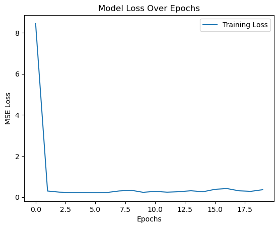

```python
# 3. Plot the loss curve
plt.plot(history.history['loss'], label='Training Loss')
#plt.plot(history.history['val_loss'], label='Validation Loss')
plt.title('Model Loss Over Epochs')
plt.xlabel('Epochs')
plt.ylabel('MSE Loss')
plt.legend()
plt.show()
```

### Now, let's build a Recurrent Neural Network (32 nodes in the hidden layer)

```python
# Building a simple RNN model
rnn_model = Sequential()
rnn_model.add(SimpleRNN(32))  # RNN with 32 units; , input_shape=(128,240, 14)
rnn_model.add(Dense(1))  # Output layer

# Compile the model
rnn_model.compile(loss='mse', optimizer='adam')

history = rnn_model.fit(train_gen, epochs=20, steps_per_epoch= 100,
                    batch_size=32)
```

```
100/100 ━━━━━━━━━━━━━━━━━━━━ 2s 12ms/step - loss: 1.1565
100/100 ━━━━━━━━━━━━━━━━━━━━ 1s 12ms/step - loss: 0.1989
100/100 ━━━━━━━━━━━━━━━━━━━━ 1s 12ms/step - loss: 0.1732
100/100 ━━━━━━━━━━━━━━━━━━━━ 1s 12ms/step - loss: 0.1582
100/100 ━━━━━━━━━━━━━━━━━━━━ 1s 12ms/step - loss: 0.1600
100/100 ━━━━━━━━━━━━━━━━━━━━ 1s 12ms/step - loss: 0.1535
100/100 ━━━━━━━━━━━━━━━━━━━━ 1s 12ms/step - loss: 0.1456
100/100 ━━━━━━━━━━━━━━━━━━━━ 1s 12ms/step - loss: 0.1449
100/100 ━━━━━━━━━━━━━━━━━━━━ 1s 12ms/step - loss: 0.1461
100/100 ━━━━━━━━━━━━━━━━━━━━ 1s 12ms/step - loss: 0.1436
100/100 ━━━━━━━━━━━━━━━━━━━━ 1s 12ms/step - loss: 0.1430
100/100 ━━━━━━━━━━━━━━━━━━━━ 1s 12ms/step - loss: 0.1382
100/100 ━━━━━━━━━━━━━━━━━━━━ 1s 12ms/step - loss: 0.1401
100/100 ━━━━━━━━━━━━━━━━━━━━ 1s 12ms/step - loss: 0.1398
100/100 ━━━━━━━━━━━━━━━━━━━━ 1s 12ms/step - loss: 0.1394
100/100 ━━━━━━━━━━━━━━━━━━━━ 1s 12ms/step - loss: 0.1383
100/100 ━━━━━━━━━━━━━━━━━━━━ 1s 12ms/step - loss: 0.1373
100/100 ━━━━━━━━━━━━━━━━━━━━ 1s 12ms/step - loss: 0.1334
100/100 ━━━━━━━━━━━━━━━━━━━━ 1s 12ms/step - loss: 0.1359
100/100 ━━━━━━━━━━━━━━━━━━━━ 1s 12ms/step - loss: 0.1382
```

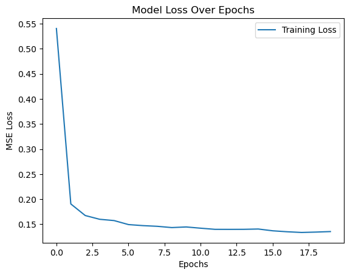

```python
# Plot the loss curve
plt.plot(history.history['loss'], label='Training Loss')
#plt.plot(history.history['val_loss'], label='Validation Loss')
plt.title('Model Loss Over Epochs')
plt.xlabel('Epochs')
plt.ylabel('MSE Loss')
plt.legend()
plt.show()
```

### Let's visually compare predictions of the MLP and RNN models

Obtain predictions:

```python
test_gen = generator(data, lookback=1440, delay= 144, min_index= 300001,
                    shuffle= True, step= 6, batch_size= 128)
X_test, y_test = next(test_gen)

# MLP predictions
mlp_pred = mlp_model.predict(X_test)
mlp_pred = mlp_pred*std[1] + mean[1]  #Rescale predictions
mlp_pred = mlp_pred.flatten()

# RNN predictions
rnn_pred = rnn_model.predict(X_test)
rnn_pred = rnn_pred*std[1] + mean[1]  #Rescale predictions
rnn_pred = rnn_pred.flatten()

# Rescale observations
y_test = y_test*std[1] + mean[1]
```

```
4/4 ━━━━━━━━━━━━━━━━━━━━ 0s 938us/step
4/4 ━━━━━━━━━━━━━━━━━━━━ 0s 3ms/step
```

Plotting:

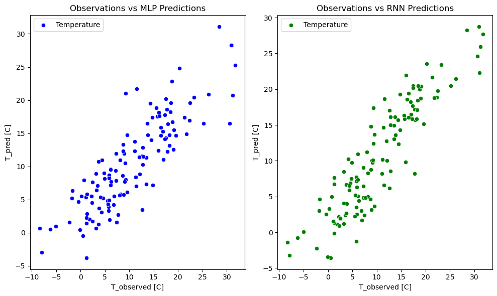

```python
# Set up the subplots with 1 row and 2 columns
fig, axes = plt.subplots(1, 2, figsize=(10, 6))

sns.scatterplot(x=y_test, y=mlp_pred, ax=axes[0], color='blue')
axes[0].set_title('Observations vs MLP Predictions')
axes[0].set_xlabel('T_observed [C]')
axes[0].set_ylabel('T_pred [C]')
axes[0].legend(['Temperature'])

sns.scatterplot(x=y_test, y=rnn_pred, ax=axes[1], color='green')
axes[1].set_title('Observations vs RNN Predictions')
axes[1].set_xlabel('T_observed [C]')
axes[1].set_ylabel('T_pred [C]')
axes[1].legend(['Temperature'])

# Display the plots
plt.tight_layout()
plt.show()
```

## In-class Excercise

**MLP Model:**

```python
rmse = np.round(np.sqrt(np.mean( (y_test - mlp_pred)**2)), 2)
print('RMSE = ', rmse, 'C')
print('NSE = ', 1 - (rmse/np.var(y_test)))
print('Pearson correlation = ', np.round(np.corrcoef(y_test, mlp_pred)[0,1], 3))
print('Relative Bias = ', np.round((np.mean(mlp_pred - y_test)/np.mean(y_test))*100), 3, ' %')
```

```
RMSE =  3.68 C
NSE =  0.9416951591937185
Pearson correlation =  0.896
Relative Bias =  2.0 3  %
```

**RNN Model:**

```python
rmse = np.round(np.sqrt(np.mean( (y_test - rnn_pred)**2)), 2)
print('RMSE = ', np.round(np.sqrt(np.mean( (y_test - rnn_pred)**2)), 2), 'C')
print('NSE = ', 1 - (rmse/np.var(y_test)))
print('Pearson correlation = ', np.round(np.corrcoef(y_test, rnn_pred)[0,1], 3))
print('Relative Bias = ', np.round((np.mean(rnn_pred - y_test)/np.mean(y_test))*100), 3, ' %')
```

```
RMSE =  2.98 C
NSE =  0.9527857539123047
Pearson correlation =  0.927
Relative Bias =  -1.0 3  %
```

Can any of the two models outperform a persistence model?

```python
rmse = np.round(np.sqrt(np.mean( (y_test[1:] - persistence)**2)), 2)
persistence = y_test[:-1]
print('RMSE = ', np.round(np.sqrt(np.mean( (y_test[1:] - persistence)**2)), 2), 'C')
print('NSE = ', 1 - (rmse/np.var(y_test)))
print('Pearson correlation = ', np.round(np.corrcoef(y_test[1:], persistence)[0,1], 3))
print('Relative Bias = ', np.round((np.mean(persistence - y_test[1:])/np.mean(y_test))*100), 3, ' %')
```

```
RMSE =  10.7 C
NSE =  0.8304723378730403
Pearson correlation =  0.097
Relative Bias =  0.0 3  %
```

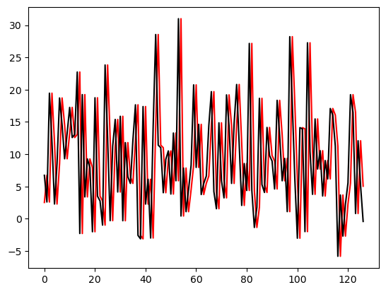

```python
plt.plot(np.arange(len(persistence)), persistence, 'r', np.arange(len(persistence)), y_test[1:], 'k')
```

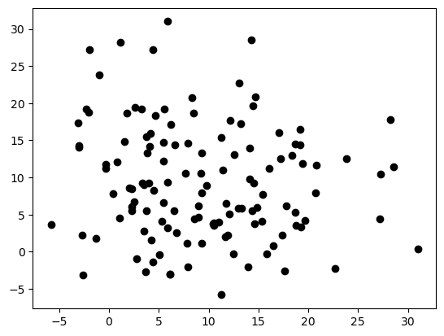

```python
plt.plot(persistence,  y_test[1:], 'ko')
```